# The economic and population effect of storm events

Samuel Chan

# Synopsis

Link to raw data: [Storm Events Database](https://www.ncdc.noaa.gov/stormevents/)

# Data Processing

- Load the required libraries

```r
library(ggplot2)
```

- Make sure the dataset (“StormData.csv”) is in the same directory, read it into the workspace using read.csv.
- Also at this step we would convert the date

```r
raw <- read.csv("StormData.csv")
raw[,2] <- as.Date(raw$BGN_DATE, "%m/%d/%Y")
data <- raw[,c(2,7,8,23,24,25,26,27,28,29)]
```

We also create a subset of the raw dataframe, containing only the variables that contribute to our analysis goals.

We see that within the data df, most of the variables are self-explanatory except for PROPDMGEXP and CROPDMGEXP. For this experiment, we had to examine the relationship between PROPDMG / PROPDMGEXP, CROPDMG / CROPDMGEXP. A simple google search suggest that **EXP means Exponent** in this dataset (although the official document neither confirmed or denied this definition).

```r
# Examine the possible values for PROPDMGEXP and CROPDMGEXP
table(data$PROPDMGEXP)
```

```
##
##             -      ?      +      0      1      2      3      4      5
## 465934      1      8      5    216     25     13      4      4     28
##      6      7      8      B      h      H      K      m      M
##      4      5      1     40      1      6 424665      7  11330
```

```r
table(data$CROPDMGEXP)
```

```
##
##             ?      0      2      B      k      K      m      M
## 618413      7     19      1      9     21 281832      1   1994
```

We see from this code chunk that the possible values for [PROP|CROP]DMGEXP are: 1. “” (empty) 2. - (single dash) 3. ? (question mark) 4. + (plus symbol) 5. 0 - 8 (numeric) 6. B 7. h 8. H 9. K 10. m 11. M

The following code chunk is purely exploratory and thus optional.

```r
# Since a lot of values in PROPDMGEXP are missing values (""), we want to see if that's indicative of no CROPDMG
head( data[data$CROPDMGEXP == "" & data$CROPDMG != 0, ] ) # 3 out of 618413 records have non-zero CROPDMG
head( data[data$PROPDMGEXP == "" & data$PROPDMG != 0, ] )

# Read a few remarks to find possible explanations where DMG != 0 but DMGEXP == 0
head(raw[raw$CROPDMGEXP == "" & raw$CROPDMG != 0, ]$REMARKS, 10)
head(raw[raw$PROPDMGEXP == "" & raw$PROPDMG != 0, ]$REMARKS, 10)
```

[output not shown]

### Dealing with “” (empty values) for[PROP|CROP]DMGEXP

We will now assign the total damage to be 0 wherever [PROP|CROP]DMGEXP == “” (empty) based on: - Our interpretation of the remarks - The fact that the non-zero dmg represents an incredibly small number from the subset (3 out of 618413, 76 out of 465934)

```r
# Create the prop.dmg and crop.dmg variables so we can update them with the actual values with prop accounted
data$prop.dmg <- data$PROPDMG
data$crop.dmg <- data$CROPDMG

# When EXP == "", set net damage to 0
data$prop.dmg[data$PROPDMGEXP == ""] <- 0
data$crop.dmg[data$CROPDMGEXP == ""] <- 0
```

### Dealing with “-” (single dash) for[PROP|CROP]DMGEXP

There is only one observation with the dash (-) value for the PROPDMGEXP (none for CROPDMGEXP). Because this observation row has no remarks, we have to assign a proponent of 10 to it. We assign 10 because it seems the most logical, albeit a speculative one at that. What is fortunate is that this is just 1 observation so it shouldn’t impact the overall analysis in any significant way.

```r
data[data$PROPDMGEXP == "-", ]
```

```
##          BGN_DATE STATE    EVTYPE FATALITIES INJURIES PROPDMG PROPDMGEXP
## 229327 1995-12-12    OR HIGH WIND          2        0      15          -
##        CROPDMG CROPDMGEXP WFO prop.dmg crop.dmg
## 229327       0                      15        0
```

```r
# When EXP == "-", set net damage to 10 * DMG
data$prop.dmg[data$PROPDMGEXP == "-"] <- data$PROPDMG[data$PROPDMGEXP == "-"] * 10
```

### Dealing with “?” for[PROP|CROP]DMGEXP

There are 8 and 7 observation values in PROPDMGEXP and CROPDMGEXP respectively with a question mark (“?”).

```r
head(data[data$PROPDMGEXP == "?", ])
```

```
##          BGN_DATE STATE             EVTYPE FATALITIES INJURIES PROPDMG
## 198689 1995-04-09    IL THUNDERSTORM WINDS          0        0       0
## 225254 1993-05-08    OK        FLASH FLOOD          0        0       0
## 227409 1993-05-08    OK        FLASH FLOOD          0        0       0
## 232016 1994-08-05    SC  THUNDERSTORM WIND          0        0       0
## 233746 1995-09-02    SD               HAIL          0        0       0
## 233747 1995-09-02    SD               HAIL          0        0       0
##        PROPDMGEXP CROPDMG CROPDMGEXP WFO prop.dmg crop.dmg
## 198689          ?       0                       0        0
## 225254          ?       0                       0        0
## 227409          ?       0                       0        0
## 232016          ?       0                       0        0
## 233746          ?       0                       0        0
## 233747          ?       0                       0        0
```

```r
head(data[data$CROPDMGEXP == "?", ])
```

```
##          BGN_DATE STATE             EVTYPE FATALITIES INJURIES PROPDMG
## 192467 1995-03-09    CA  FLASH FLOOD WINDS          0        0    0.41
## 197066 1993-02-12    GA THUNDERSTORM WINDS          0        0    0.50
## 197331 1993-02-12    GA THUNDERSTORM WINDS          0        0    0.50
## 220300 1995-07-31    NC THUNDERSTORM WINDS          0        0    0.00
## 220877 1995-02-16    NC  FLOOD/FLASH FLOOD          0        0  400.00
## 232901 1995-08-26    SC  FLOOD/FLASH FLOOD          0        0    0.50
##        PROPDMGEXP CROPDMG CROPDMGEXP WFO prop.dmg crop.dmg
## 192467                  0          ?          0.0        0
## 197066          K       0          ?          0.5        0
## 197331          K       0          ?          0.5        0
## 220300                  0          ?          0.0        0
## 220877          K       0          ?        400.0        0
## 232901          M       0          ?          0.5        0
```

All the corresponding PROPDMG and CROPDMG are zero, so we will set net damage to 0.

```r
# When EXP == "-", set net damage to 0
data$prop.dmg[data$PROPDMGEXP == "?"] <- 0
data$crop.dmg[data$CROPDMGEXP == "?"] <- 0
```

### Dealing with “+” for[PROP|CROP]DMGEXP

There are only five observation with the dash (+) value for the PROPDMGEXP (none for CROPDMGEXP). We access the REMARKS column to study what possible value to assign as a proponent for this value. For good measure, we also cross-check with the NOAA website using the records where PROPDMGEXP == “+”. We decide with a proponent of 1. Since default prop.dmg == PROPDMGEXP, we don’t need to transform the value additionally.

```r
data[data$PROPDMGEXP == "+", ]
raw[data$PROPDMGEXP == "+", ]$REMARKS
```

[output not shown]

### Dealing with 0-8 for[PROP|CROP]DMGEXP

There are 216 and 19 observation values in PROPDMGEXP and CROPDMGEXP respectively with a 0 value.

```r
head(data[data$PROPDMGEXP == 0, ])
```

```
##          BGN_DATE STATE      EVTYPE FATALITIES INJURIES PROPDMG PROPDMGEXP
## 189004 1994-12-03    AK  HIGH TIDES          0        0   150.0          0
## 191375 1994-08-10    CO FLASH FLOOD          0        0    50.0          0
## 191376 1994-08-10    CO   LIGHTNING          0        0     5.0          0
## 191377 1994-08-11    CO   LIGHTNING          0        0    37.0          0
## 192303 1994-01-27    CA  HEAVY SNOW          0        0     0.0          0
## 192524 1994-08-12    CA     TORNADO          0        0     0.5          0
##        CROPDMG CROPDMGEXP WFO prop.dmg crop.dmg
## 189004       0                   150.0        0
## 191375       0                    50.0        0
## 191376       0                     5.0        0
## 191377       0                    37.0        0
## 192303       0                     0.0        0
## 192524       0                     0.5        0
```

```r
head(data[data$CROPDMGEXP == 0, ])
```

```
##          BGN_DATE STATE             EVTYPE FATALITIES INJURIES PROPDMG
## 192758 1995-05-07    CO               HAIL          0        0     0.0
## 194391 1993-11-28    DE THUNDERSTORM WINDS          0        0     0.5
## 194518 1994-10-28    FL            TORNADO          0        0     5.0
## 196458 1995-07-17    GA               HAIL          0        0     0.0
## 200544 1994-10-06    IA THUNDERSTORM WINDS          0        0     5.0
## 200888 1995-05-27    IA            TORNADO          0        0   100.0
##        PROPDMGEXP CROPDMG CROPDMGEXP WFO prop.dmg crop.dmg
## 192758                  0          0          0.0        0
## 194391          K       0          0          0.5        0
## 194518          K       0          0          5.0        0
## 196458                 20          0          0.0       20
## 200544          K       5          0          5.0        5
## 200888          K      50          0        100.0       50
```

If we extract the observation #196458 (Georgia, CROPDMG 20) and #200888 (Iowa, CROPDMG 50), and again check it against the [NOAA website] (https://www.ncdc.noaa.gov/stormevents/), we see that it a CROPDMGEXP value of 0 represents a proponent of 10 (Access the link to NOAA).

The Database list a crop damage of $0.2K (=$200) for the #196458 event, which is CROPDMG * 10. Other checks using matching records confirm this. In fact, any CROPDMGEXP or PROPDMGEXP with a value of 0 to 8 (numeric) all represents a proponent of 10.

```r
# When EXP %in% c("0","1","2","3","4","5","6","7","8"), set net damage to 10 * DMG
num <- c("0","1","2","3","4","5","6","7","8")
data[data$PROPDMGEXP %in% num, 11] <- data$PROPDMG[data$PROPDMGEXP %in% num] * 10
data[data$CROPDMGEXP %in% num, 12] <- data$CROPDMG[data$CROPDMGEXP %in% num] * 10
```

### Dealing with “B” for[PROP|CROP]DMGEXP

There are 40 and 9 observation values in PROPDMGEXP and CROPDMGEXP respectively with a “B” value. In our investigation, we use the REMARKS variable of two random observations, one where PROPDMGEXP == “B” and the other where CROPDMGEXP == “B”

```r
head(data[data$PROPDMGEXP == "B", ])
```

```
##          BGN_DATE STATE                     EVTYPE FATALITIES INJURIES
## 187564 1993-03-12    AL               WINTER STORM          4        0
## 187566 1995-10-04    AL  HURRICANE OPAL/HIGH WINDS          2        0
## 195000 1995-10-03    FL             HURRICANE OPAL          1        0
## 195001 1993-03-12    FL TORNADOES, TSTM WIND, HAIL         25        0
## 195007 1995-10-04    FL             HURRICANE OPAL          0        0
## 198389 1993-08-31    IL                RIVER FLOOD          0        0
##        PROPDMG PROPDMGEXP CROPDMG CROPDMGEXP WFO prop.dmg crop.dmg
## 187564     5.0          B     0.0                     5.0      0.0
## 187566     0.1          B    10.0          M          0.1     10.0
## 195000     2.1          B     5.0          M          2.1      5.0
## 195001     1.6          B     2.5          M          1.6      2.5
## 195007     1.0          B     0.0                     1.0      0.0
## 198389     5.0          B     5.0          B          5.0      5.0
```

```r
head(data[data$CROPDMGEXP == "B", ])
```

```
##          BGN_DATE STATE            EVTYPE FATALITIES INJURIES PROPDMG
## 188633 1995-08-20    AL              HEAT          0        0    0.00
## 198389 1993-08-31    IL       RIVER FLOOD          0        0    5.00
## 199733 1995-08-01    IA           DROUGHT          0        0    0.00
## 201256 1995-09-21    IA            FREEZE          0        0    0.00
## 211900 1994-02-09    MS         ICE STORM          0        0  500.00
## 581537 2005-08-29    MS HURRICANE/TYPHOON         15      104    5.88
##        PROPDMGEXP CROPDMG CROPDMGEXP WFO prop.dmg crop.dmg
## 188633               0.40          B         0.00     0.40
## 198389          B    5.00          B         5.00     5.00
## 199733               0.50          B         0.00     0.50
## 201256               0.20          B         0.00     0.20
## 211900          K    5.00          B       500.00     5.00
## 581537          B    1.51          B JAN     5.88     1.51
```

```r
b.p <- raw[raw$PROPDMGEXP == "B", c("PROPDMG", "REMARKS")]
c.p <- raw[raw$CROPDMGEXP == "B", c("CROPDMG", "REMARKS")]
b.p[3,]
```

```
##        PROPDMG
## 195000     2.1
##                                                                                                                                                                                                                                                                                                          …
## 195000 Hurricane Opal moved across the Gulf of Mexico on October 3 and 4.  The spiral bands started affecting the Northwest Florida area Tuesday and continued until the storm moved ashore Wednesday afternoon.  The center of the storm moved ashore at almost the same location as Hurricane Erin did …
```

```r
c.p[1,]
```

```
##        CROPDMG
## 188633     0.4
##                                                                                                                                                                                                                                                                                                          …
## 188633 Hot, dry weather was a problem for Alabama throughout the month.  New record high temperatures were set in a number of cities with Critical Heat Alerts in effect for many days during the month.  Birmingham, for example, hit 100 degrees or higher on seven consecutive days from the 13th to t…
```

We observe that the PROPDMG of 2.1 with a PROPDMGEXP of “B” is remarked as a “preliminary damage … (amounting to) $2.1 billion dollars”. Similarly, in the second random test, we observe that the CROPDMG of 0.4 with a CROPDMGEXP of “B” is remarked as follow: “the poulty industry was hit hard along with a number of crops … the $400 million crop damage is just an estimate”. We conclude that “B” do in fact stand for “billion”.

```r
# When EXP == "B", set net damage to 1000000000 * DMG
data$prop.dmg[data$PROPDMGEXP == "B"] <- data$PROPDMG[data$PROPDMGEXP == "B"] * 1000000000
data$crop.dmg[data$CROPDMGEXP == "B"] <- data$CROPDMG[data$CROPDMGEXP == "B"] * 1000000000
```

### Dealing with H/h, K/k and M/m for[PROP|CROP]DMGEXP

With “B” representing “billion”, it’s not too far-fetched to guess the remaining possible values of EXP: - H / h: Hundred - K / k: Thousand - M / m: Million

We can verify this accordingly using grep to look for “hundred”, “thousand”, “million” in the remarks:

```r
# Verify M == million (x1000000)
m.p <- raw[raw$PROPDMGEXP == "M" | raw$PROPDMGEXP == "m", c("PROPDMG", "REMARKS")]
head(m.p[grep("million", m.p$REMARKS, fixed=T),],2)
```

```
##        PROPDMG
## 187581      25
## 187583      48
##                                                                                                                                                                                                                                                                                                          …
## 187581                                                                                                                                                                                                                                                                                                   …
## 187583 Hurricane Opal moved through Northwest Florida at the Okaloosa and Santa Rosa County line into South Alabama near the Escambia and Covington County line on Wednesday evening around 1830 CST.  Opal moved rapidly north northeast through Covington and Crenshaw Counties and into Montgomery Cou…
```

- Notice our first observation row 187581 list PROPDMG as 25 with “m” as its exponent value, and the remark confirmed that “preliminary damage estimates were 25 million”.
- Notice our second observation row 187583list PROPDMG as 48 with “m” as its exponent value, and the remark confirmed that “preliminary damage estimates were 48 million with half of that being from tree damage in the Conecuh National Forest.”

We can use the above method to verify the K/k and H/h values in our EXP variable

```r
# Verify k == thousands (x1000)
raw[188466, c("PROPDMG", "CROPDMG", "PROPDMGEXP", "REMARKS")]
```

```
##        PROPDMG CROPDMG PROPDMGEXP
## 188466     200       0          K
##                                                                                                                                                     REMARKS
## 188466 Lightning struck a house under construction in west Mobile.  The home was almost completely destroyed.  The loss was estimated to be $200 thousand.
```

With those proof, we now assign the appropriate damage value

```r
# When EXP == [h|H] , set net damage to 100 * DMG
data$prop.dmg[data$PROPDMGEXP == "H" | data$PROPDMGEXP == "h"] <- data$PROPDMG[data$PROPDMGEXP == "H" | data$PROPDMGEXP == "h"] * 100
# neither "H" nor "h" in CROPDMGEXP variable

# When EXP == [k|K] , set net damage to 1000 * DMG
data$prop.dmg[data$PROPDMGEXP == "K" | data$PROPDMGEXP == "k"] <- data$PROPDMG[data$PROPDMGEXP == "K" | data$PROPDMGEXP == "k"] * 1000
data$crop.dmg[data$CROPDMGEXP == "K" | data$CROPDMGEXP == "k"] <- data$CROPDMG[data$CROPDMGEXP == "K" | data$CROPDMGEXP == "k"] * 1000

# When EXP == [m|M] , set net damage to 1000000 * DMG
data$prop.dmg[data$PROPDMGEXP == "M" | data$PROPDMGEXP == "m"] <- data$PROPDMG[data$PROPDMGEXP == "M" | data$PROPDMGEXP == "m"] * 1000000
data$crop.dmg[data$CROPDMGEXP == "M" | data$CROPDMGEXP == "m"] <- data$CROPDMG[data$CROPDMGEXP == "M" | data$CROPDMGEXP == "m"] * 1000000
```

# Results

- Across the United States, which types of events (as indicated in the 𝙴𝚅𝚃𝚈𝙿𝙴 variable) are most harmful with respect to population health?
- Across the United States, which types of events have the greatest economic consequences?

We will now examine the relationship between event types and fatalities using ggplot2. This will give us an idea of the impact these different types of events have on population health.

## Analysis 1: Types of storm events that are most harmful with respect to population health

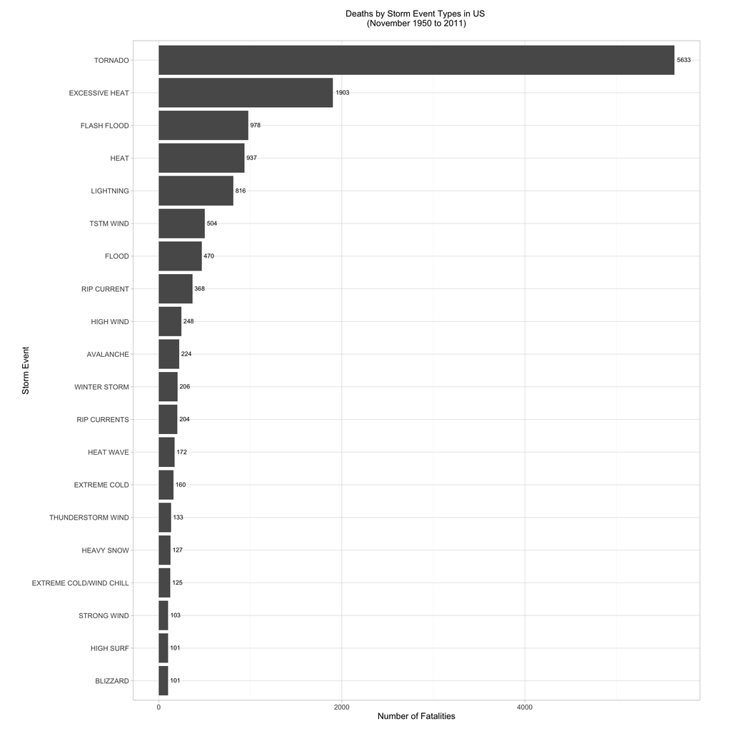

```r
# Aggregate to get the summary statistics of fatalities by event type
fatal.sum.byEV <- aggregate(data$FATALITIES, by=list(data$EVTYPE), sum)

# Rename the columns
colnames(fatal.sum.byEV) <- c("Event", "Fatalities")

# Order the dataset by Fatalities in decreasing order and select only events that has contributed to at least 100 deaths during the observation period (1950 to November 2011)
fatal.sum.sort.byEV <- fatal.sum.byEV[ with(fatal.sum.byEV, order(-Fatalities)), ]
fatal.100 <- fatal.sum.sort.byEV[fatal.sum.sort.byEV$Fatalities >= 100, ]

ggplot(fatal.100, aes(x=reorder(Event, Fatalities), y=Fatalities)) + geom_bar(stat="identity") + coord_flip() + geom_text(aes(label=Fatalities), vjust=0.4, hjust=-0.2, size=3) + theme_light() + labs(x = "Storm Event", y = "Number of Fatalities", title="Deaths by Storm Event Types in US \n (November 1950 to 2011) \n") + theme(plot.title=element_text(size=12), plot.margin=unit(c(0.5,1.5,0.5,1), "cm"))
```

We observe that Tornado is the storm event that has the greatest impact on population health, being responsible for 5,633 deaths alone between November 1950 to 2011. This is followed by excessive heat at 1903 deaths. Flash flood, Heat, lightning and thunderstorm wind events are third to sixth in that order, with each event type resulting in more than 500 deaths.

## Analysis 2: Types of events that have the greatest economic consequences over the course of 1950 to 2011

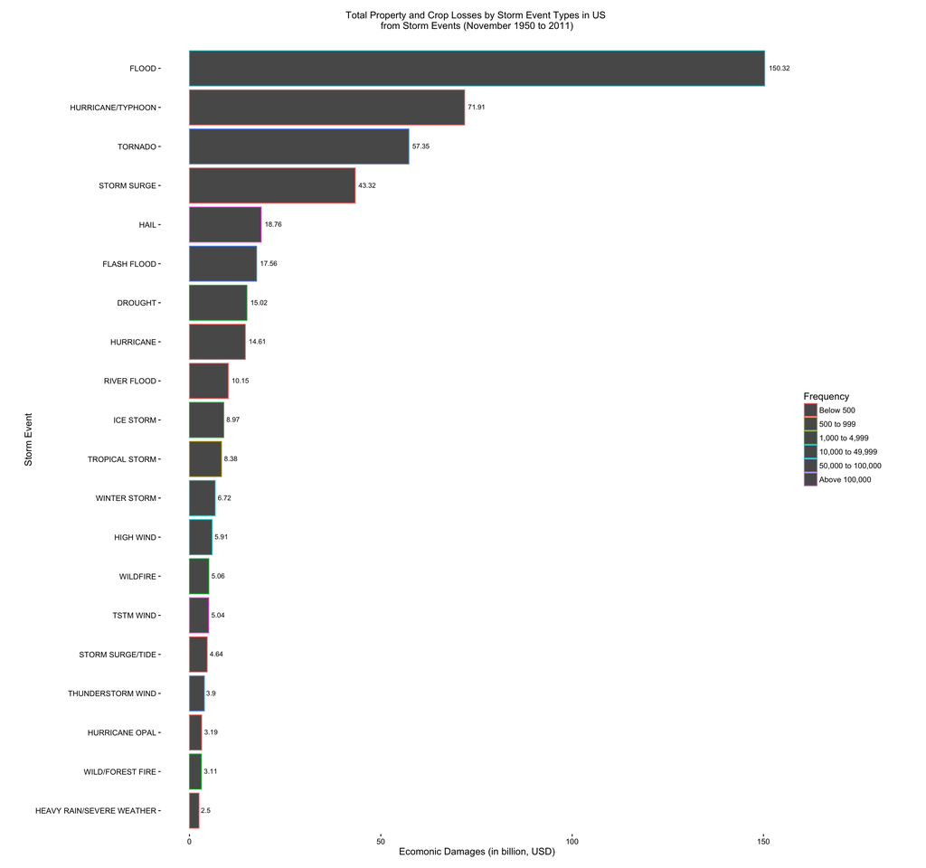

```r
# Create a variable called 'econ' that store the combined economic losses
data$econ <- data$prop.dmg + data$crop.dmg

# Aggregate to get the summary statistics of economic losses by event type
econ.byEV <- aggregate(data$econ, by=list(data$EVTYPE), sum)

# Create frequency groups using cut
econ.freq <- aggregate(data$econ, by=list(data$EVTYPE), length)
econ.freq$group <- cut(econ.freq$x, breaks = c(0, 500, 1000, 5000, 10000, 50000, 100000, Inf), labels = c("Below 500", "500 to 999", "1,000 to 4,999", "5,000 to 9,999", "10,000 to 49,999", "50,000 to 100,000", "Above 100,000"), right = FALSE)

# Combine the freq columns to the original dataframe
econ.byEV <- cbind(econ.byEV, econ.freq$group)

# Order the dataset by their combined economic losses in decreasing order
econ.sort.byEV <- econ.byEV[with(econ.byEV, order(-x)), ]

# Select only the top 20, and rename the columns
econ.20 <- econ.sort.byEV[1:20, ]
colnames(econ.20) <- c("Event", "EconomicDmg", "Frequency")
econ.20$dmgB <- round((econ.20$EconomicDmg / 1000000000), digits=2)

ggplot(econ.20, aes(x=reorder(Event, dmgB), y=dmgB)) + geom_bar(stat="identity", aes(colour=Frequency)) + coord_flip() + geom_text(aes(label=dmgB), vjust=0.4, hjust=-0.2, size=3) + theme_classic() + labs(x = "Storm Event", y = "Ecomonic Damages (in billion, USD)", title="Total Property and Crop Losses by Storm Event Types in US \n from Storm Events (November 1950 to 2011) \n") + theme(plot.title=element_text(size=12), plot.margin=unit(c(0.5,1.5,0.5,1), "cm"))
```

## Analysis 3: Types of events that, on average, causes the most potent economic damages

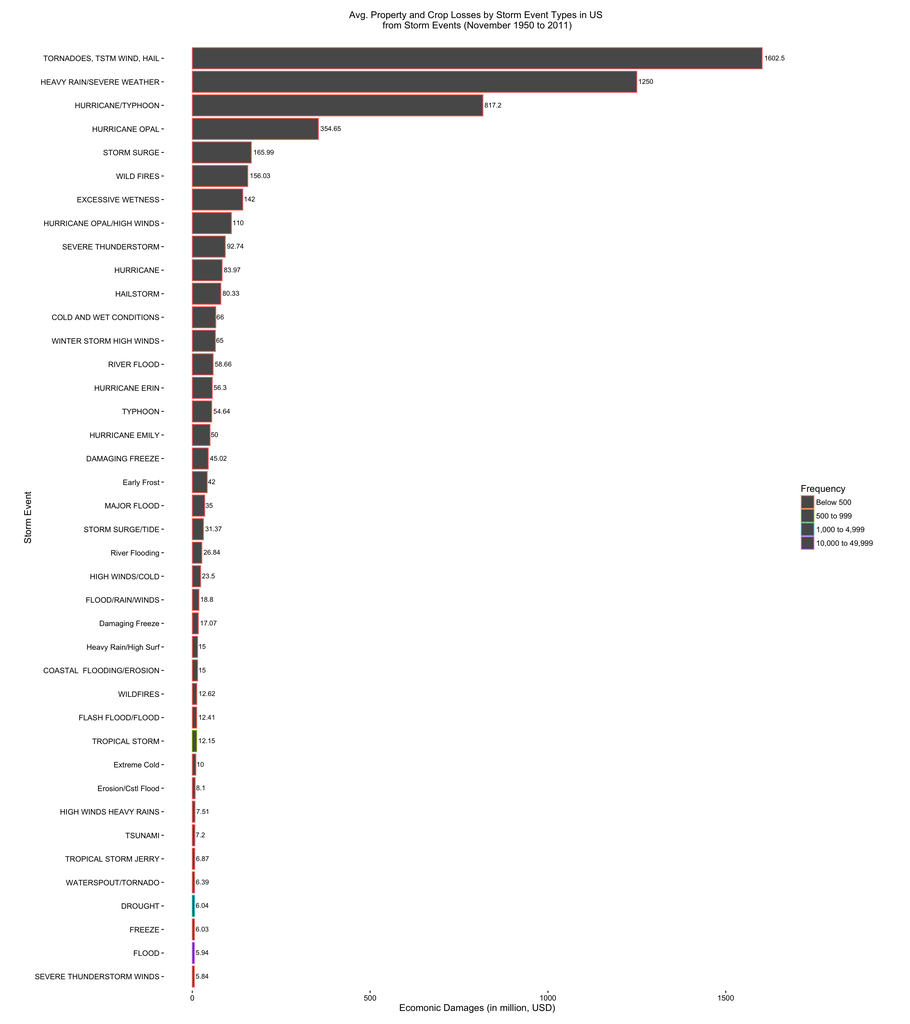

```r
# Aggregate to get the summary statistics of economic damages by event type
econ.avg.byEV <- aggregate(data$econ, by=list(data$EVTYPE), mean)

# Combine the freq columns to the original dataframe
econ.avg.byEV <- cbind(econ.avg.byEV, econ.freq$group)

# Order the dataset by their avg economic damages in decreasing order
econ.sort.avg <- econ.avg.byEV[with(econ.avg.byEV, order(-x)), ]

# Select only the top 40, and rename the columns
econ.avg40 <- econ.sort.avg[1:40, ]
colnames(econ.avg40) <- c("Event", "AvgEcoDmg", "Frequency")

econ.avg40$dmgM <- round((econ.avg40$AvgEcoDmg / 1000000), digits = 2 )

ggplot(econ.avg40, aes(x=reorder(Event, dmgM), y=dmgM)) + geom_bar(stat="identity", aes(colour=Frequency)) + coord_flip() + geom_text(aes(label=dmgM), vjust=0.4, hjust=-0.1, size=3) + theme_classic() + labs(x = "Storm Event", y = "Ecomonic Damages (in million, USD)", title="Avg. Property and Crop Losses by Storm Event Types in US \n from Storm Events (November 1950 to 2011) \n") + theme(plot.title=element_text(size=12), plot.margin=unit(c(0.5,1.2,0.5,1), "cm"))
```

While **flood** on the overall has caused the greatest amount of economic losses, it’s per-unit damage is relatively low compared to the others. It’s contribution to economic damages however can be observed from it’s fairly high frequency of occurance.

# Further Observations and Recommendations

Throughout the preparation of this report, a few inconsistencies in the original dataset from NOAA can be observed.

```r
raw[188395, c("PROPDMG", "CROPDMG", "PROPDMGEXP", "REMARKS")]
```

```
##        PROPDMG CROPDMG PROPDMGEXP
## 188395     500       0          K
##                                                                                                                                                                                                                                                                 REMARKS
## 188395 A tornado moved a short distance through Boaz, destroying a barn and a garage.  Also, the roof was blown off a storage building.  The winds drove several two-by-four posts into the side of a building.  Damage was estimated at approximately $100 thousand.
```

```r
raw[188476, c("PROPDMG", "CROPDMG", "PROPDMGEXP", "REMARKS")]
```

```
##        PROPDMG CROPDMG PROPDMGEXP
## 188476     500       0          K
##                                                                                                                                                                 REMARKS
## 188476 Lightning struck the central office tower at the Monroeville Telephone Company leaving thousands without telephone service and causing about $60,000 in damage.
```

Notice for observation #188395, while the damage was remarked to be “approximately $100 thousand”, it was recorded as $500 thousand instead. Similarly for observation #188476, while it was remarked that the lightning “caused about $60,000 in damage” it was recorded as $500 thousand. One possible explanation could be such that the remarks was based on an early estimation, and subsequent damages – to property or crops – were updated in the respective field the initial observation stood and hence the remarks may have just captured the partial amount of the full losses. It is not possible and unproductive for us to speculate on the reasons of such discrepancies, but these findings must be noted in this report to inform readers of its limitations and hopefully call for a more robust process in data collection.

```r
econ.freq[15:25, ]
```

```
##                        Group.1   x     group
## 15               APACHE COUNTY   1 Below 500
## 16      ASTRONOMICAL HIGH TIDE 103 Below 500
## 17       ASTRONOMICAL LOW TIDE 174 Below 500
## 18                    AVALANCE   1 Below 500
## 19                   AVALANCHE 386 Below 500
## 20                BEACH EROSIN   1 Below 500
## 21               Beach Erosion   1 Below 500
## 22               BEACH EROSION   3 Below 500
## 23 BEACH EROSION/COASTAL FLOOD   1 Below 500
## 24                 BEACH FLOOD   2 Below 500
## 25  BELOW NORMAL PRECIPITATION   2 Below 500
```

A second recommendation is regarding the consistency of terminologies, variables and values in the online Storm Data software program as well as on the preparer’s part. Notice how there are duplicate names for what is highly likely to be a single event type: [18] AVALACE and [19]AVALANCHE; [20] BEACH EROSIN, [21] Beach Erosion, [22] BEACH EROSION and [23] BEACH EROSION/COASTAL FLOOD

# APPENDIX: Description of the Variables in the ‘data’ dataframe

- BGN_DATE: The approximate time the event started to have an impact (health / economic)
- STATE: State code
- EVTYPE: An individual type of event, e.g High Wind, Blizzard, Tornado etc.
- FATALITIES: Number of fatalities
- INJURIES: Number of injuries
- PROPDMG: Damage to property
- PROPDMGEXP: Exponent of recorded damage to property
- CROPDMG: Damage to crops
- CROPDMGEXP: Exponent of recorded damage to crops
- WFO: Weather Forecast Offices, see a list or WFO names on [NOAA website] (http://www.nws.noaa.gov/emwin/wfos.htm)